# Leaderboards for Subchallenge I

Attila Gabor

11/25/2019

# 1 Overview

Here we report some statistics about subchallenge I and evaluate the leaderboard.

Some statistics about challenge I:

- the number of total submissions: 127.
- the number of submissions per rounds
  - round 1: 33
  - round 2: 59
  - round 3: 35
- the number of teams participated in this sub challenge: 39

Submissions that are better then the reference models improved from round 1 to round 2, but not to final round.

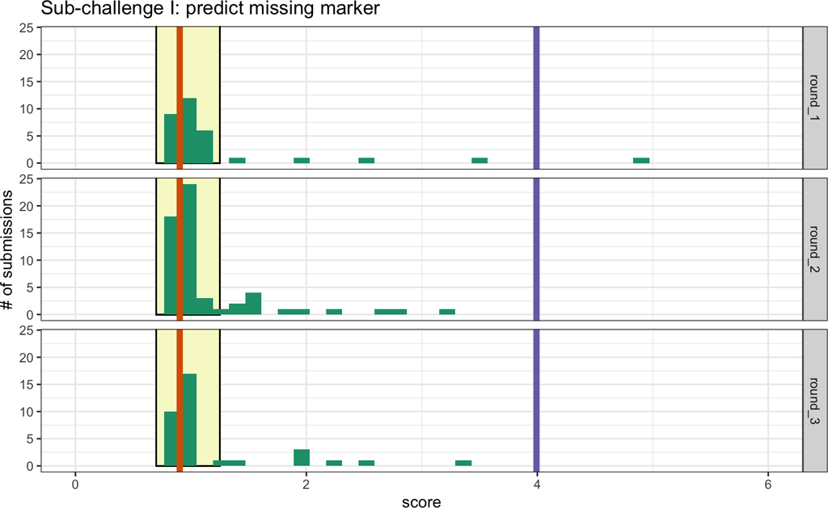

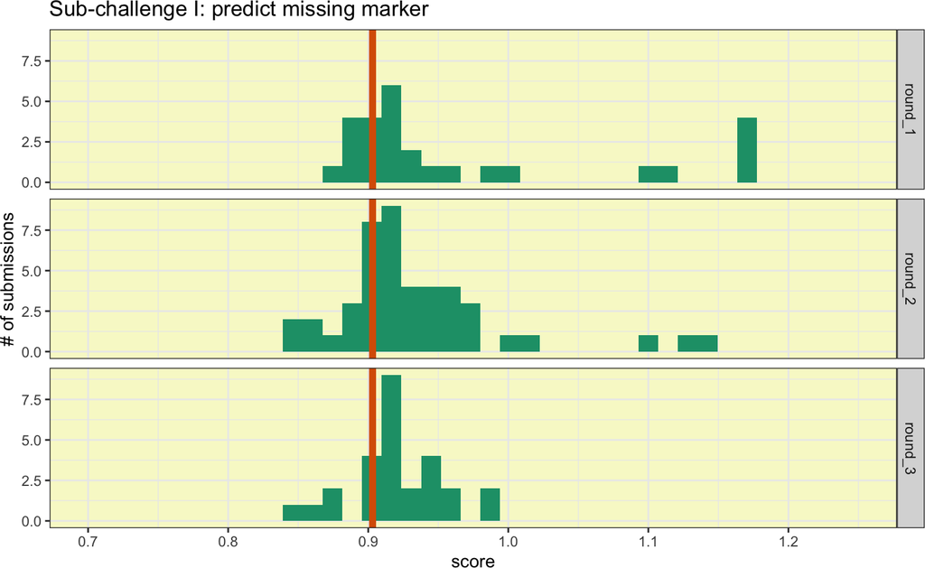

# 2 Leaderboards

Next figure shows all the submissions. We report the scores of each team, the y-axis is capped at 1.2 for better visualisation around the best teams. We ordered the teams by their last submission as we agreed to rank them accordingly. The shape of the points indicate in which round they submitted that predictions.

Some teams did not submit in the final rounds in some cases the final submissions were worst than the previous ones.

Here we go though the best teams as they are ranked on the figure. In all cases the write-ups need to be checked.

TODO: decide what to do with the teams that didnt submit in the final round. This could influence the 3rd place.

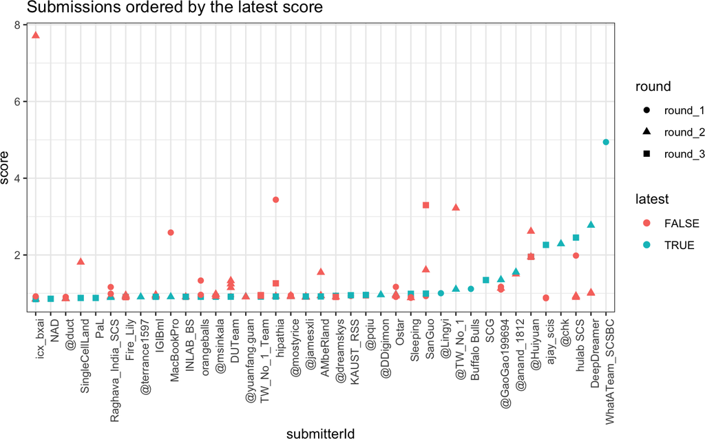

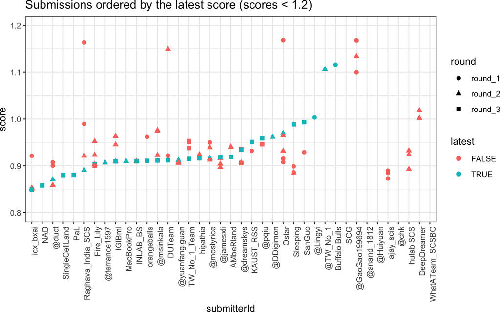

## 2.1 Strict leaderboard

- only teams with submission to round 3
- judging by their latest submission.

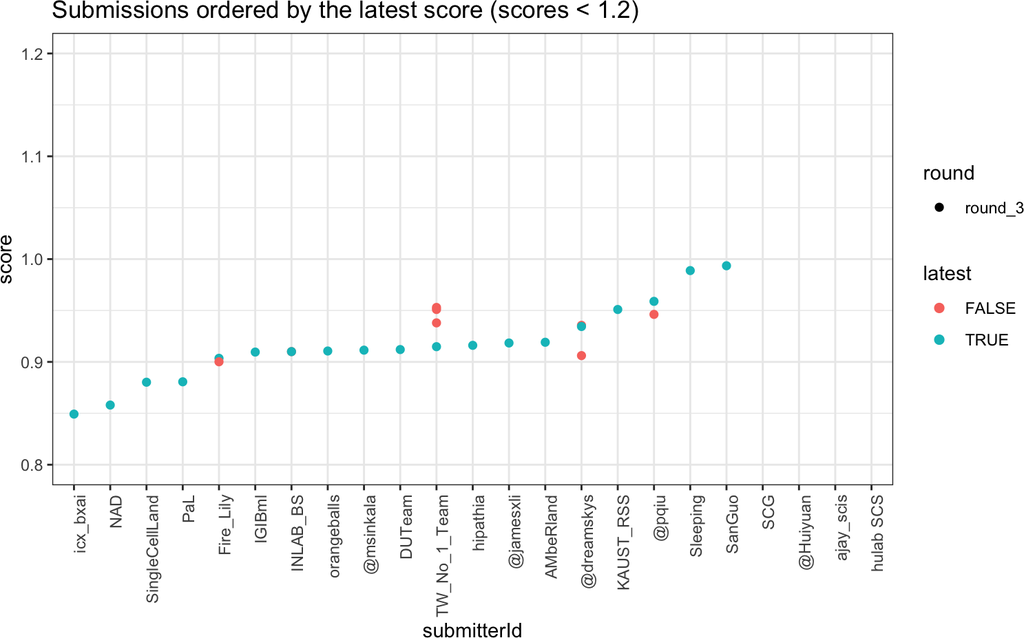

```
## # A tibble: 23 x 3
##    createdOn           submitterId    score
##    <dttm>              <chr>          <dbl>
##  1 2019-11-15 12:21:00 icx_bxai       0.849
##  2 2019-11-08 20:34:00 NAD            0.858
##  3 2019-11-10 16:52:00 SingleCellLand 0.880
##  4 2019-11-10 22:26:00 PaL            0.881
##  5 2019-11-15 19:38:00 Fire_Lily      0.904
##  6 2019-11-15 15:25:00 IGIBml         0.910
##  7 2019-11-15 19:00:00 INLAB_BS       0.910
##  8 2019-11-15 22:53:00 orangeballs    0.911
##  9 2019-11-02 18:32:00 @msinkala      0.911
## 10 2019-11-13 11:46:00 DUTeam         0.912
## 11 2019-11-07 20:41:00 TW_No_1_Team   0.915
## 12 2019-11-14 14:26:00 hipathia       0.916
## 13 2019-11-15 20:01:00 @jamesxli      0.918
## 14 2019-11-15 18:28:00 AMbeRland      0.919
## 15 2019-11-15 10:01:00 @dreamskys     0.934
## 16 2019-11-15 21:06:00 KAUST_RSS      0.951
## 17 2019-11-13 05:35:00 @pqiu          0.959
## 18 2019-11-15 14:56:00 Sleeping       0.989
## 19 2019-11-13 16:53:00 SanGuo         0.994
## 20 2019-11-14 16:28:00 SCG            1.35
## 21 2019-11-14 21:35:00 @Huiyuan       1.95
## 22 2019-11-07 06:09:00 ajay_scis      2.26
## 23 2019-11-15 15:46:00 hulab SCS      2.45
```

## 2.2 Leaderboard based on best score

- teams with any submission
- judging by the best score.

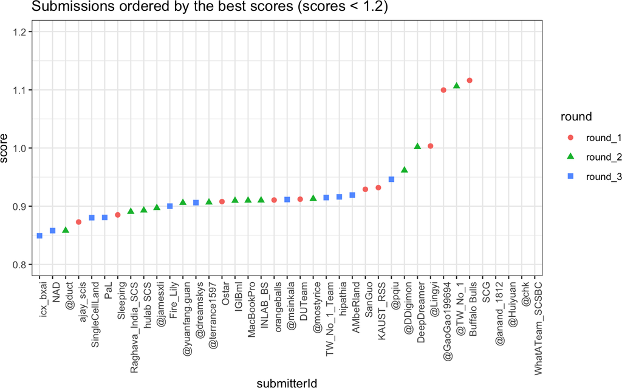

```
## # A tibble: 39 x 4
##    createdOn           submitterId       score round
##    <dttm>              <chr>             <dbl> <chr>
##  1 2019-11-15 12:21:00 icx_bxai          0.849 round_3
##  2 2019-11-08 20:34:00 NAD               0.858 round_3
##  3 2019-10-08 09:13:00 @duct             0.858 round_2
##  4 2019-09-28 12:36:00 ajay_scis         0.873 round_1
##  5 2019-11-10 16:52:00 SingleCellLand    0.880 round_3
##  6 2019-11-10 22:26:00 PaL               0.881 round_3
##  7 2019-09-29 21:43:00 Sleeping          0.885 round_1
##  8 2019-10-30 19:02:00 Raghava_India_SCS 0.891 round_2
##  9 2019-10-13 17:16:00 hulab SCS         0.893 round_2
## 10 2019-10-30 20:06:00 @jamesxli         0.897 round_2
## 11 2019-11-15 18:17:00 Fire_Lily         0.900 round_3
## 12 2019-10-28 17:53:00 @yuanfang.guan    0.906 round_2
```

[output cut: 27 more lines]

## 2.3 Leaderboard based on latest submission

- teams with any submission
- judging by the latest score.

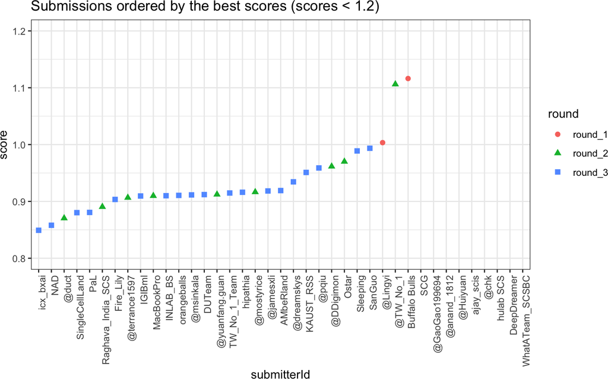

```
## # A tibble: 39 x 5
##    createdOn           submitterId       score round   latest
##    <dttm>              <chr>             <dbl> <chr>   <lgl>
##  1 2019-11-15 12:21:00 icx_bxai          0.849 round_3 TRUE
##  2 2019-11-08 20:34:00 NAD               0.858 round_3 TRUE
##  3 2019-10-22 07:44:00 @duct             0.870 round_2 TRUE
##  4 2019-11-10 16:52:00 SingleCellLand    0.880 round_3 TRUE
##  5 2019-11-10 22:26:00 PaL               0.881 round_3 TRUE
##  6 2019-10-30 19:02:00 Raghava_India_SCS 0.891 round_2 TRUE
##  7 2019-11-15 19:38:00 Fire_Lily         0.904 round_3 TRUE
##  8 2019-10-29 06:06:00 @terrance1597     0.907 round_2 TRUE
##  9 2019-11-15 15:25:00 IGIBml            0.910 round_3 TRUE
## 10 2019-10-12 19:16:00 MacBookPro        0.910 round_2 TRUE
## 11 2019-11-15 19:00:00 INLAB_BS          0.910 round_3 TRUE
## 12 2019-11-15 22:53:00 orangeballs       0.911 round_3 TRUE
```

[output cut: 27 more lines]